# Vectors, Matrices, Homogeneous Systems, and Null Space

Brody Erlandson

# Column Vectors and Matrices

## Column Vectors

We have given a brief introduction to the structure of Matrices and Vectors at the beginning of this course. Now we will more formally define the column vector, and we will visualize them in the next lecture. Previously we looked at the row view of the system of equations, we can look at these past systems with the column view too. Which we will explore this next lecture. First, lets start with the definitions.

### Definition 2.1.

A **column vector** is an ordered list of complex numbers, written in a vertical array:

$$\mathbf{v} =
\begin{bmatrix}
v_1\\
v_2\\
...\\
v_n
\end{bmatrix} \text{, where } v_i \in \mathbb{C}$$

The number in position $i$ of the vector $\mathbf{v}$ is the $i^{th}$ entry or component of $\mathbf{v}$, written as $[\mathbf{v}]_i$. We will often abbreviate ”column vector” as ”vector”.

Sometimes we call numbers scalars to distinguish them from vectors. Vectors are usually written with bold font, $\mathbf{x}$, and scalars unbolded, $x$.

Below we can visualize 3 vectors in $\mathbb{R}^2$ space. Particularly, these vectors are $\begin{bmatrix} 0\\ 1\\ \end{bmatrix}, \ \begin{bmatrix} 1\\ 0\\ \end{bmatrix}, \ \begin{bmatrix} -.5\\ -.5\\ \end{bmatrix}$.

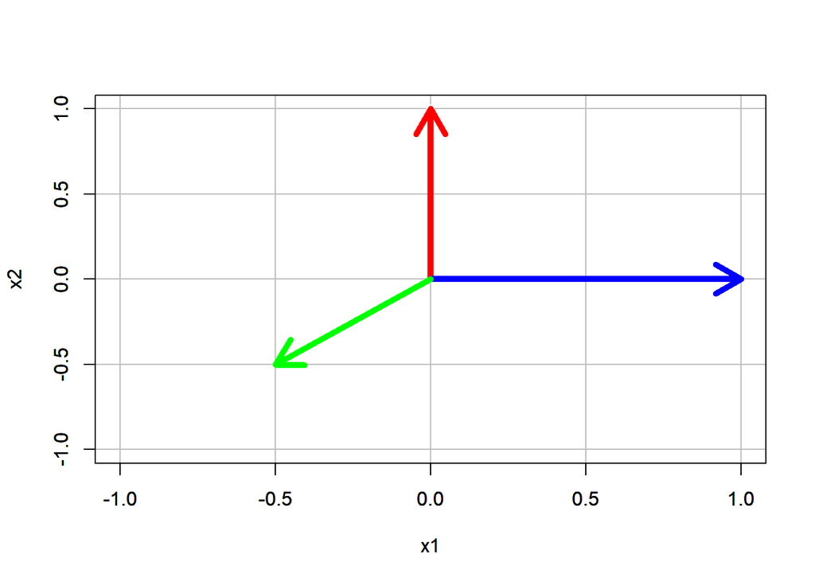

```r
plot(0, 1, col="white", xlim=c(-1, 1), ylim=c(-1,1), ylab="x2", xlab = "x1")

# Vertical grid
axis(1, tck = 1, lty = 1, col = "gray")

# Horizontal grid
axis(2, tck = 1, lty = 1, col = "gray")

par(new=TRUE)

plot(0, 1, col="white", xlim=c(-1, 1), ylim=c(-1,1), ylab="x2", xlab = "x1")
arrows(0,0,0,1, lwd=5, col="red")
arrows(0,0,1,0, lwd=5, col="blue")
arrows(0,0,-.5,-.5, lwd=5, col="green")
box()
```

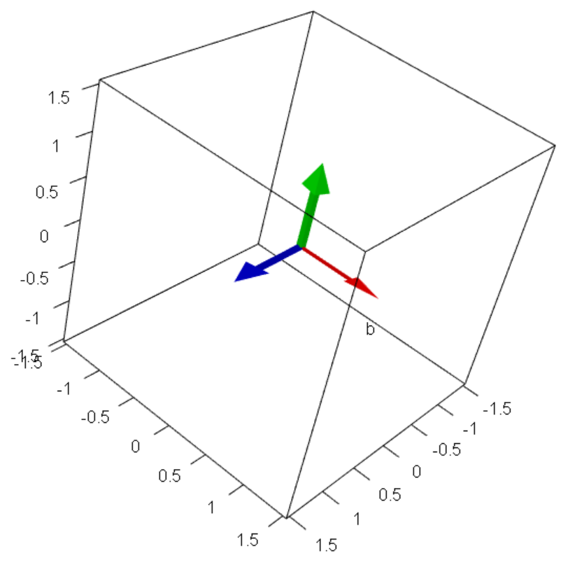

### Definition 2.2.

A vector with $n$ numbers in it is called **n-dimensional.**

### Definition 2.3.

**n-Dimensional Space**

The set of all n-dimensional vectors is called $\mathbb{C}^n$, or **n-dimensional space**.

In general, the numbers we will use are the Complex Numbers ($\mathbb{C}^n$). If we limit our scalars to the Real Numbers, then set of all n-dimensional vectors is $\mathbb{R}^n$. Familiar examples are the x-y plane, which is $\mathbb{R}^2$, and 3-dimensional space which is $\mathbb{R}^3$.

### Definition 2.4.

**Zero Vector**

The zero vector in $\mathbb{C}^n$, $\mathbf{0}$, is defined as $[\mathbf{0}]i = 0$, $i = 1, 2, ..., n$. We often write the zero vector as
$$\mathbf{0} =
\begin{bmatrix}
0\\
0\\
\vdots \\
0
\end{bmatrix}$$
to emphasize that all the entries are zero.

## Matrices

Again, we have defined the general structure of a matrix previously. We will now more formally define what a matrix is.

### Definition 2.5.

**Matrix** An $m \times n$ matrix is a rectangular array of Complex numbers, with $m$ rows and $n$ columns, written as

$$\mathbf{A} = \begin{bmatrix}
a_{11} & \dots & a_{1n}\\
\vdots & \ddots & \vdots\\
a_{m1} & \dots & a_{mn}
\end{bmatrix} \text{, where } a_{ij} \in \mathbb{C}$$

where the variables $a_{ij}$ inside the matrix represent the numbers in row $i$ and column $j$. We also use the notation $[\mathbf{A}]_{ij}$ to indicate the number in row $i$ and column $j$ of matrix $\mathbf{A}$. We sometimes use the simpler notation:

$$\mathbf{A} = \begin{bmatrix}
\mathbf{a}_{1}\ |\ \mathbf{a}_{2}\ |\ \dots\ |\ \mathbf{a}_{n}\\
\end{bmatrix} \text{, where } \mathbf{a}_{j} \in \mathbb{C}^m$$

# General Systems of Equations

So far we have only talked about systems that are explicitly defined. However, we will now formally define a general system.

## Definition 3.1.

**System of Linear Equations**

A system of linear equations is a set of m equations in the variables $x_1, x_2, ..., x_n$ of the following form:

$$a_{11}x_1 + a_{12}x_2 + \dots + a_{1n}x_n = b_1 \\
a_{21}x_1 + a_{22}x_2 + \dots + a_{2n}x_n = b_2 \\
\vdots \\
a_{m1}x_1 + a_{m2}x_2 + . . . + a_{mn}x_n = b_m$$

where $a_{ij},\ b_i,\ x_j \in \mathbb{C}$.

## Definition 3.2.

**Solution to A System of Linear Equations**

A solution of a system of linear equations in n variables $x_1, x_2, \dots, x_n$ is an ordered list $(s_1, s_2, \dots, s_n)$ where $s_i \in \mathbb{C}$ such that if $s_i$ is substituted for $x_i$ for all $i = 1, 2, \dots, n$ in every equation of the system, then every equation in the system will be true simultaneously.

## Definition 3.3.

**Solution Set**

The solution set of a system of linear equations is the set of all solutions to the system.

## Definition 3.4.

**Consistent and Inconsistent Systems**

If the solution set of a system of linear equations is non-empty, then the system is *consistent*. If the solution set is empty, the system is *inconsistent*.

## Definition 3.5.

**Coefficient Matrix, Solution Vector, Constant Vector, Augmented Matrix**

Given the system of linear equations:

$$a_{11}x_1 + a_{12}x_2 + \dots + a_{1n}x_n = b_1 \\
a_{21}x_1 + a_{22}x_2 + \dots + a_{2n}x_n = b_2 \\
\vdots \\
a_{m1}x_1 + a_{m2}x_2 + . . . + a_{mn}x_n = b_m$$

the matrix $\mathbf{A}$ is the *coefficient matrix* of the system:

$$\mathbf{A} = \begin{bmatrix}
a_{11} & \dots & a_{1n}\\
\vdots & \ddots & \vdots\\
a_{m1} & \dots & a_{mn}
\end{bmatrix}$$

the vector $\mathbf{x}$ is the *solution vector* of the system:

$$\mathbf{x} =
\begin{bmatrix}
x_1\\
x_2\\
...\\
x_n
\end{bmatrix}$$

the vector $\mathbf{b}$ is the *constant vector* of the system:

$$\mathbf{b} =
\begin{bmatrix}
b_1\\
b_2\\
...\\
b_n
\end{bmatrix}$$

and the *augmented matrix* of the system is the $m \times (n + 1)$ matrix: $[\mathbf{A|b}] = [\mathbf{a_{1}\ |\ a_{2}\ |\ \dots\ |\ a_{n}\ |\ b}]$

## Definition 3.6.

**Matrix Representation of a System**

The matrix representation of a system of equations with coefficient matrix $\mathbf{A}$ and constant vector $\mathbf{b}$ is $\mathcal{LS}(\mathbf{A}, \mathbf{b})$.

# Homogeneous Systems

## Definition 4.1.

**Homogeneous System**

The linear system $\mathcal{LS}(\mathbf{A}, \mathbf{0})$ is called a homogeneous system. In other words, a system is homogeneous if its constant vector is zero. Here is a general $\mathbf{m} \times \mathbf{n}$ homogeneous system:

$$\mathbf{Ax=0}$$

## Definition 4.2.

**Trivial Solution**

The solution vector $\mathbf{x = 0}$ is called the trivial solution to a system of linear equations. In the trivial solution, every value of every variable is zero.

We can visualize this pretty easily in $\mathbb{R}^2$ where $\mathbf{A} = \begin{bmatrix} 2 & -1\\ 4 & 8 \end{bmatrix}$

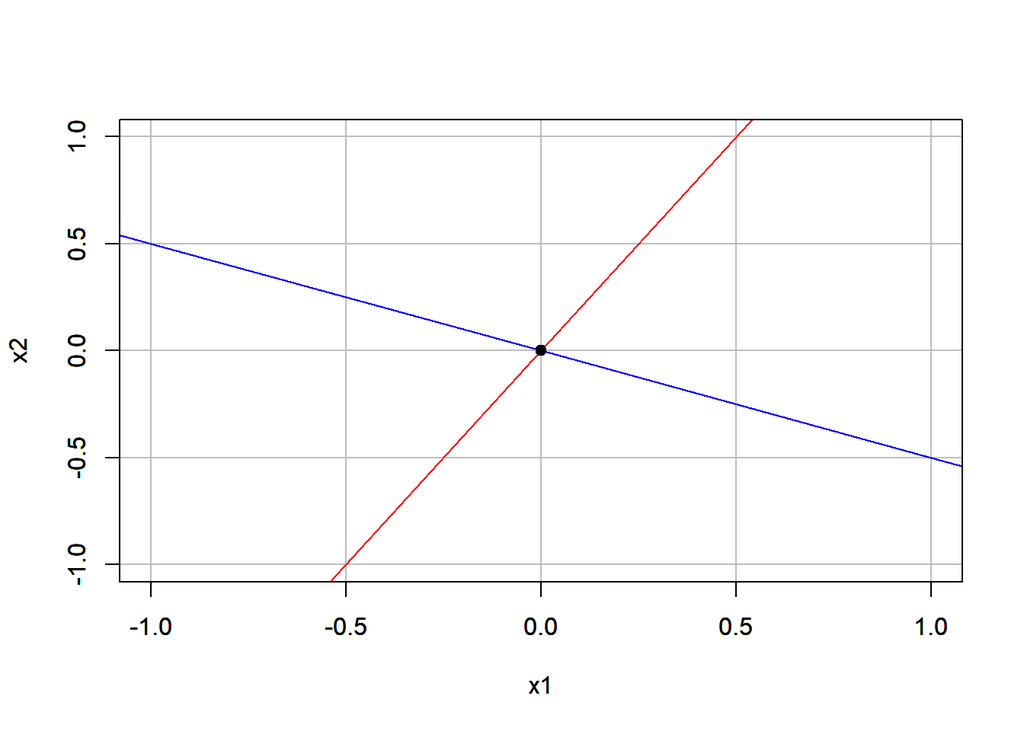

```r
x <- -2:6
y1 <- 2*x
y2 <- -(1/2)*x

plot(x, y1, "l", col="red", xlim=c(-1, 1), ylim=c(-1,1), ylab="x2", xlab = "x1")

# Vertical grid
axis(1, tck = 1, lty = 1, col = "gray")

# Horizontal grid
axis(2, tck = 1, lty = 1, col = "gray")

par(new=TRUE)

plot(x, y1, "l", col="red", xlim=c(-1, 1), ylim=c(-1,1), ylab="x2", xlab = "x1")
lines(x, y2, col="blue")
points(0, 0, pch=19, col="black")

box()
```

If we put it in equation notation, we would have a y-intercept of 0.

## Theorem 4.1.

**Homogeneous Systems are Consistent**

Every homogeneous system has the trivial solution, and is therefore consistent.

*Proof.* Consider an arbitrary homogeneous linear system of $m$ equations in $n$ variables:

$$\mathbf{A_{m \times n}x_{n \times 1} = 0_{n \times 1}}$$

let $\mathbf{x_{n \times 1} = 0_{n \times 1}}$, this gives us $\mathbf{A_{m \times n}0_{n \times 1} = 0_{n \times 1}}$, which can be written out as:

$$a_{11}0 + a_{12}0 + \dots + a_{1n}0 = 0 \\
\vdots \\
a_{m1}0 + a_{m2}0 + \dots + a_{mn}0 = 0$$

Every equation in the system is clearly satisfied. $\blacksquare$

# Null Space

## Definition 4.3.

**Null Space**

The null space of an $m \times n$ matrix $\mathbf{A}$, written $\mathcal{N}(\mathbf{A})$, is the solution set of the system $\mathcal{LS}(\mathbf{A}, \mathbf{0})$.